# R Notebook

# Experimental Design and Data Analysis: Assignment 4

## Assignment 4

First of all, we load the libraries needed for the assignments.

```r
library(mvtnorm)
library(multcomp)
library(lme4)
```

### Exercise 1

```r
bread = read.table('bread.txt')
environment=as.factor(bread$environment)
humidity=as.factor(bread$humidity)
hours=as.numeric(bread$hours)
```

#### 1

Here after is a randomization process for this database. The first element is temperature, with cold=1, intermediate=2 and warm=3; the second, humidity, where dry=1 and wet=2; and finally, the third is the time to decay in hours.

```r
I=3; J=2; N=3;
rand=sample(50:500, N*I*J)
rbind(rep(1:I,each=N*J), rep(1:J,N*I), rand)
```

```
     [,1] [,2] [,3] [,4] [,5] [,6] [,7] [,8] [,9] [,10] [,11] [,12] [,13] [,14] [,15] [,16] [,17] [,18]
        1    1    1    1    1    1    2    2    2     2     2     2     3     3     3     3     3     3
        1    2    1    2    1    2    1    2    1     2     1     2     1     2     1     2     1     2
rand  253  366   88  321   73  444  279  449  334    53   466   456   495   162   257   452   492   465
```

#### 2

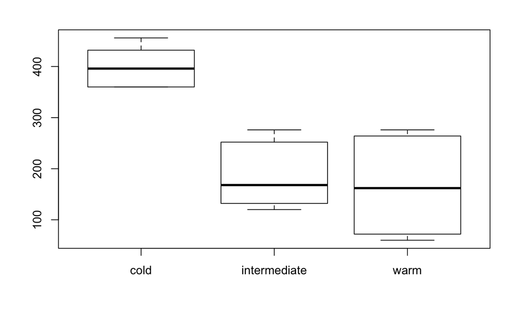

```r
boxplot(hours~environment,data=bread)
```

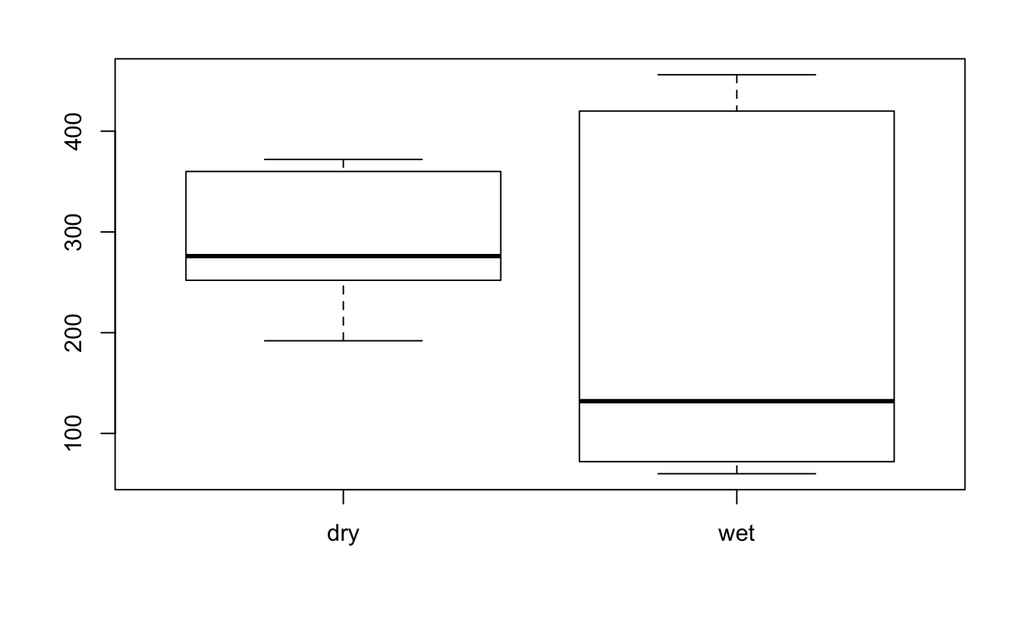

```r
boxplot(hours~humidity,data=bread)
```

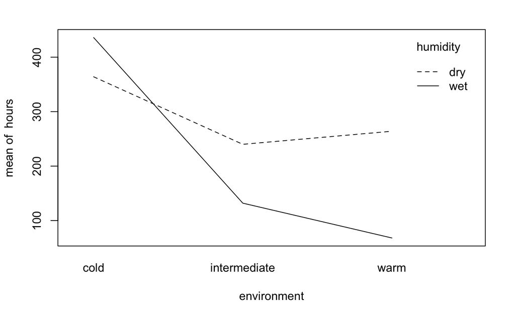

```r
interaction.plot(environment,humidity,hours)
```

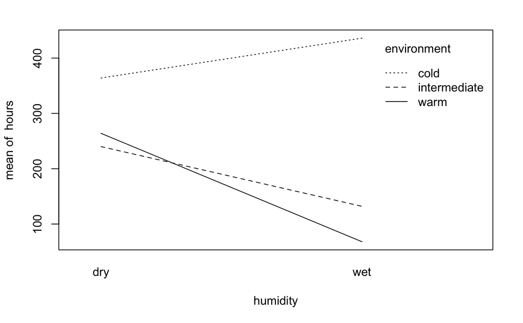

```r
interaction.plot(humidity,environment,hours)
```

#### 3

We will now perform an analysis of variance to test for effect of the factors temperature, humidity, and their interaction.

```r
breadvar=lm(hours~environment*humidity,data=bread)
anova(breadvar)
```

```
Analysis of Variance Table

Response: hours
                     Df Sum Sq Mean Sq F value    Pr(>F)
environment           2 201904  100952 233.685 2.461e-10 ***
humidity              1  26912   26912  62.296 4.316e-06 ***
environment:humidity  2  55984   27992  64.796 3.705e-07 ***
Residuals            12   5184     432
---
Signif. codes:  0 ‘***’ 0.001 ‘**’ 0.01 ‘*’ 0.05 ‘.’ 0.1 ‘ ’ 1
```

The analysis of variance above gives us the coefficients for the linear model. As it can be seen in the F value column, the coefficient related to the environment temperature has a value of 233.685, while the one related to humidity had a value of 62.296, which is almost four times lower. Their interaction had a value of 64.796, which is a value very close to the coefficient attached to humidity alone.

#### 4

```r
summary(breadvar)
```

```
Call:
lm(formula = hours ~ environment * humidity, data = bread)

Residuals:
   Min     1Q Median     3Q    Max
   -48     -7      0     11     36

Coefficients:
                                    Estimate Std. Error t value Pr(>|t|)
(Intercept)                           364.00      12.00  30.333 1.03e-12 ***
environmentintermediate              -124.00      16.97  -7.307 9.39e-06 ***
environmentwarm                      -100.00      16.97  -5.893 7.34e-05 ***
humiditywet                            72.00      16.97   4.243  0.00114 **
environmentintermediate:humiditywet  -180.00      24.00  -7.500 7.23e-06 ***
environmentwarm:humiditywet          -268.00      24.00 -11.167 1.07e-07 ***
---
Signif. codes:  0 ‘***’ 0.001 ‘**’ 0.01 ‘*’ 0.05 ‘.’ 0.1 ‘ ’ 1

Residual standard error: 20.78 on 12 degrees of freedom
Multiple R-squared:  0.9821,    Adjusted R-squared:  0.9747
F-statistic: 131.9 on 5 and 12 DF,  p-value: 4.676e-10
```

Here, we observe in more details the coefficients for each one of the classes in each variable. In general, when the humidity is wet, it affects positively the hours for decay with coefficient 72.00; however, when combined to an intermediate or warm environment temperature, these coefficients drop to -180.00and -268.00, respectively. However, the environment temperature when intermediate or warm, affect both ways negatively the hours for decay with coefficients -124.00 and -100.00, respectively. Thus, it is not correct to afirm that either one or the other variable has the greatest numerical influence on decay, as it has been observed that the importante of humidity changes if combined with certain conditions of the environment temperature.

#### 5

The following procedure will help us to look for outliers in the dataset.

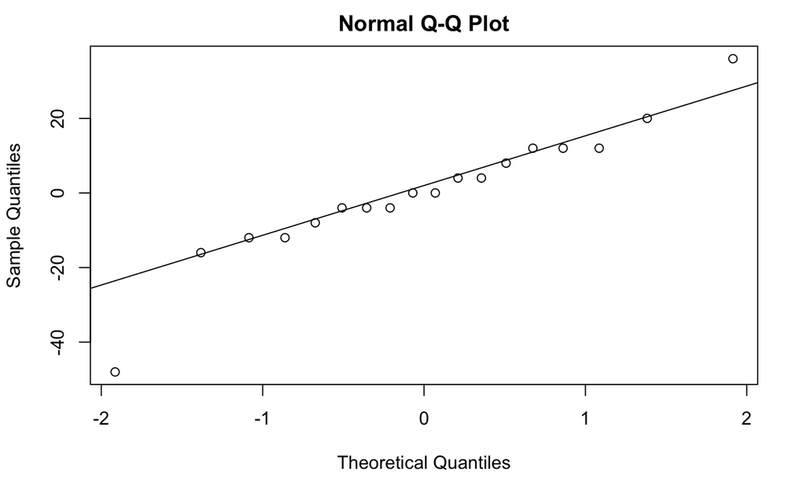

```r
qqnorm(residuals(breadvar))
qqline(residuals(breadvar))
```

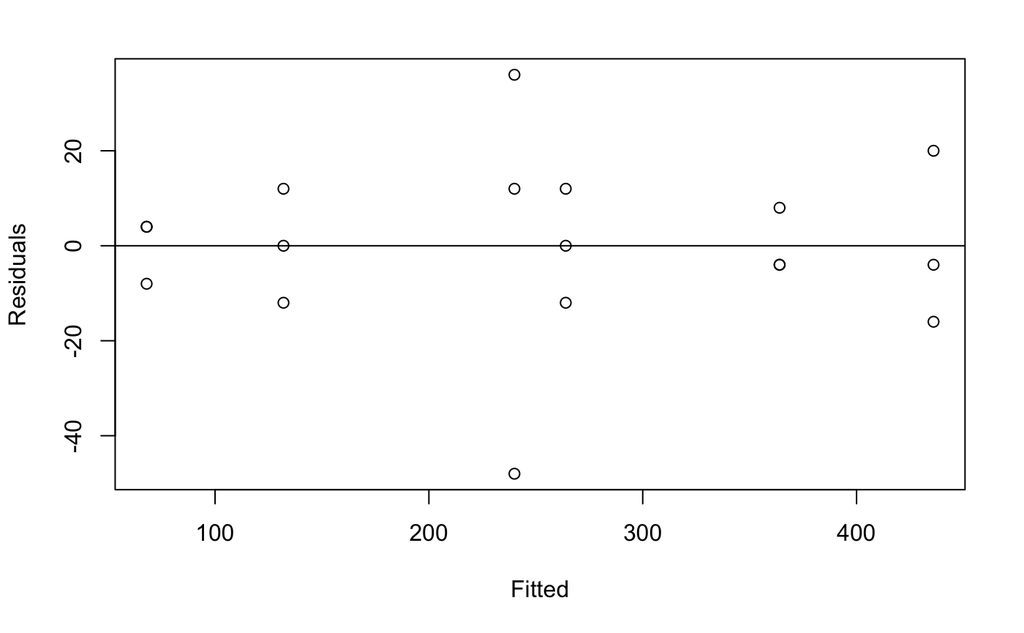

```r
plot(fitted(breadaov2),residuals(breadaov2),xlab="Fitted",ylab="Residuals")
abline(h=0)
```

From the last figure, it is clear that most of points have residuals in the linear model, however it two extreme points could be considered as outliers, one with value around 40 and the one with value around -50.

### Exercise 2

```r
search = read.table('search.txt')
time=as.numeric(search$time)
skill=as.numeric(search$skill)
interface=as.numeric(search$interface)
```

#### 1

Here after is a randomization process for this database. The first element is skill; the second, interface; and finally, the third is the time to find the product.

```r
I=5; J=3; N=1;
rand=sample(15:30, I*J)
rbind(rep(1:I,each=1), rep(1:J,each=5), rand)
```

```
     [,1] [,2] [,3] [,4] [,5] [,6] [,7] [,8] [,9] [,10] [,11] [,12] [,13] [,14] [,15]
        1    2    3    4    5    1    2    3    4     5     1     2     3     4     5
        1    1    1    1    1    2    2    2    2     2     3     3     3     3     3
rand   25   16   21   17   27   18   30   15   29    24    26    22    20    28    23
```

#### 2

Here after, we will create a contigency table to better see how the two variables “skill” and “interface” are correlated. In general, when the skill values are lower - thus, higher skills - the time to find the product is lower. Furthermore, the effect of the interfaces is also important as the time to find the product seems to increase, in general, in the direction of Interface 1-> Interface 2-> Interface 3.

```r
xtabs(time~interface+skill)
```

```
         skill
interface    1    2    3    4    5
        1 16.1 14.5 17.6 21.1 21.5
        2 15.6 20.4 19.8 24.8 23.7
        3 20.5 21.2 23.9 22.2 25.3
```

[figure not shown]

```r
par(mfrow=c(1,2))
boxplot(time~interface, xlab="Interface", ylab="time")
boxplot(time~skill, xlab="Skill", ylab="time")
```

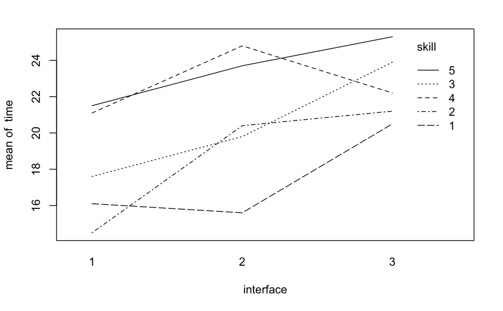

```r
interaction.plot(interface,skill,time)
```

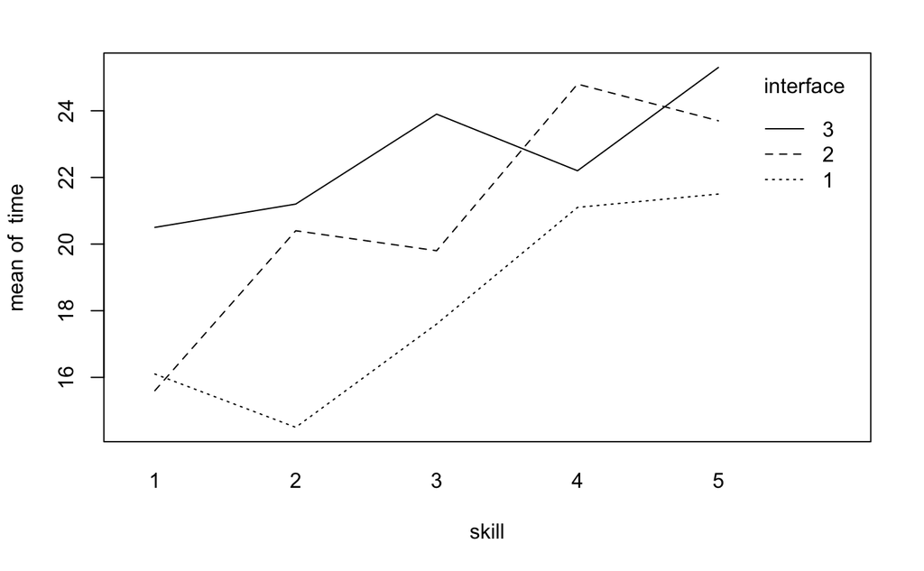

```r
interaction.plot(skill,interface,time)
```

Finally, we create interaction plots to better understand how these variables interact. Fixing the values of the skill values, time increases when going from interface 1 to 2, except for when the skills have value 1. The same can be said for when going from interface 2 to 3, except for when the skills have value 4. Similarly, we analyse the interaction plot now fixing the interface values. The first interface seems to be faster used by those with skill 2; the second, by those with skill 1, and the third likewise. However, interface 3 seems to be also user-friendly for people with skill of 4, as there is an important downward slope from skill 3 to 4.

#### 3

```r
searchvar=lm(time~interface+skill,data=search)
anova(searchvar)
```

```
Analysis of Variance Table

Response: time
          Df Sum Sq Mean Sq F value    Pr(>F)
interface  1 49.729  49.729  21.422 0.0005817 ***
skill      1 78.732  78.732  33.916 8.165e-05 ***
Residuals 12 27.856   2.321
---
Signif. codes:  0 ‘***’ 0.001 ‘**’ 0.01 ‘*’ 0.05 ‘.’ 0.1 ‘ ’ 1
```

#### 4

```r
summary(aovsearch)
```

```
Call:
lm(formula = time ~ interface + skill, data = search)

Residuals:
    Min      1Q  Median      3Q     Max
-2.5733 -0.6967  0.3867  1.0567  1.7867

Coefficients:
            Estimate Std. Error t value Pr(>|t|)
(Intercept)   15.013      1.227  12.238 1.85e-06 ***
interface2     2.700      1.136   2.377  0.04474 *
interface3     4.460      1.136   3.927  0.00438 **
skill2         1.300      1.466   0.887  0.40118
skill3         3.033      1.466   2.069  0.07238 .
skill4         5.300      1.466   3.614  0.00684 **
skill5         6.100      1.466   4.160  0.00316 **
---
Signif. codes:  0 ‘***’ 0.001 ‘**’ 0.01 ‘*’ 0.05 ‘.’ 0.1 ‘ ’ 1

Residual standard error: 1.796 on 8 degrees of freedom
Multiple R-squared:  0.8349,    Adjusted R-squared:  0.7111
F-statistic: 6.745 on 6 and 8 DF,  p-value: 0.008395
```

#### 5

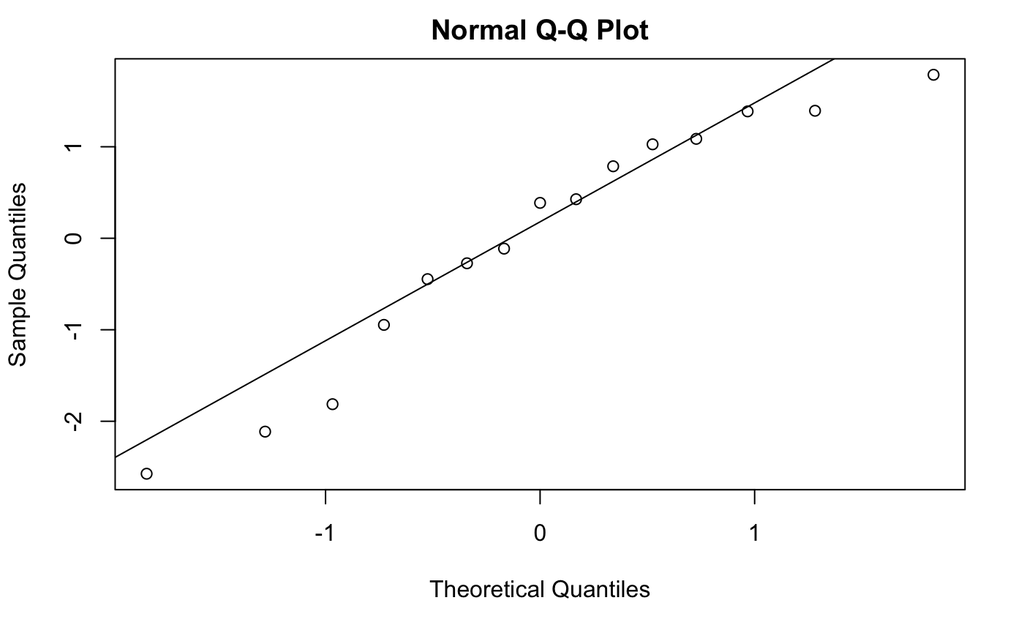

```r
qqnorm(residuals(aovsearch))
qqline(residuals(aovsearch))
```

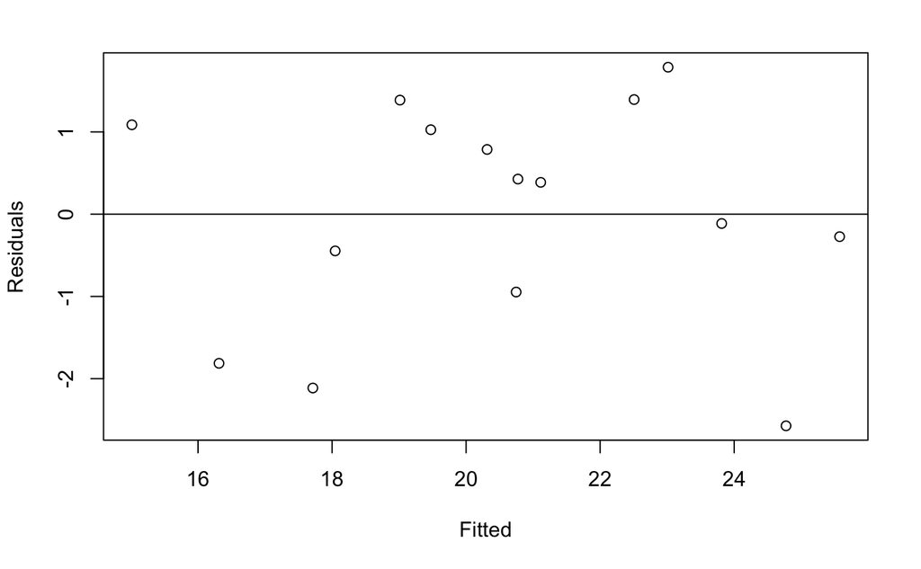

```r
plot(fitted(aovsearch),residuals(aovsearch),xlab="Fitted",ylab="Residuals")
abline(h=0)
```

#### 6

```r
friedman.test(time,interface,skill)
```

```
    Friedman rank sum test

data:  time, interface and skill
Friedman chi-squared = 6.4, df = 2, p-value = 0.04076
```

#### 7

```r
search_noskill=search[,-c(2)]
search_noskill$interface=as.factor(search_noskill$interface)
aovsearch_noskill=lm(time~interface,data=search_noskill)
anova(aovsearch_noskill)
```

```
Analysis of Variance Table

Response: time
          Df  Sum Sq Mean Sq F value  Pr(>F)
interface  2  50.465  25.233  2.8605 0.09642 .
Residuals 12 105.852   8.821
---
Signif. codes:  0 ‘***’ 0.001 ‘**’ 0.01 ‘*’ 0.05 ‘.’ 0.1 ‘ ’ 1
```

### Exercise 3

```r
cream = read.table('cream.txt')
acidity=as.factor(cream$acidity)
batch=as.factor(cream$batch)
position=as.factor(cream$position)
starter=as.factor(cream$starter)
```

#### 1

```r
aovcream=lm(acidity~starter+batch+position,data=cream)
```

[output not shown]

#### 2

```r
summary(aovcream)
```

[output not shown]

#### 3

```r
library(multcomp)
multcream=glht(aovcream,linfct=mcp(starter="Tukey"))
summary(multcream)
```

```
     Simultaneous Tests for General Linear Hypotheses

Multiple Comparisons of Means: Tukey Contrasts


Fit: lm(formula = acidity ~ starter + batch + position, data = cream)

Linear Hypotheses:
           Estimate Std. Error t value Pr(>|t|)
2 - 1 == 0  -0.1500     0.4673  -0.321 0.997367
3 - 1 == 0  -0.9800     0.4673  -2.097 0.282065
4 - 1 == 0   2.8100     0.4673   6.013 0.000536 ***
5 - 1 == 0  -0.4840     0.4673  -1.036 0.834319
3 - 2 == 0  -0.8300     0.4673  -1.776 0.428830
4 - 2 == 0   2.9600     0.4673   6.334 0.000296 ***
5 - 2 == 0  -0.3340     0.4673  -0.715 0.949087
4 - 3 == 0   3.7900     0.4673   8.110  < 1e-04 ***
5 - 3 == 0   0.4960     0.4673   1.061 0.822272
5 - 4 == 0  -3.2940     0.4673  -7.048  < 1e-04 ***
---
Signif. codes:  0 ‘***’ 0.001 ‘**’ 0.01 ‘*’ 0.05 ‘.’ 0.1 ‘ ’ 1
(Adjusted p values reported -- single-step method)
```

```r
summary(aovcream)
```

```
Call:
lm(formula = acidity ~ starter + batch + position, data = cream)

Residuals:
    Min      1Q  Median      3Q     Max
-1.2836 -0.2336  0.0384  0.3584  1.0204

Coefficients:
            Estimate Std. Error t value Pr(>|t|)
(Intercept)   8.6616     0.5329  16.255 1.55e-09 ***
starter2     -0.1500     0.4673  -0.321   0.7538
starter3     -0.9800     0.4673  -2.097   0.0579 .
starter4      2.8100     0.4673   6.013 6.10e-05 ***
starter5     -0.4840     0.4673  -1.036   0.3208
batch2       -1.3480     0.4673  -2.884   0.0137 *
batch3        0.2760     0.4673   0.591   0.5658
batch4        1.3680     0.4673   2.927   0.0127 *
batch5        0.2000     0.4673   0.428   0.6763
position2    -0.6180     0.4673  -1.322   0.2107
position3    -0.0380     0.4673  -0.081   0.9365
position4    -0.7640     0.4673  -1.635   0.1280
position5    -0.2640     0.4673  -0.565   0.5825
---
Signif. codes:  0 ‘***’ 0.001 ‘**’ 0.01 ‘*’ 0.05 ‘.’ 0.1 ‘ ’ 1

Residual standard error: 0.7389 on 12 degrees of freedom
Multiple R-squared:  0.9088,    Adjusted R-squared:  0.8175
F-statistic:  9.96 on 12 and 12 DF,  p-value: 0.0001777
```

```r
summary(multcream)
```

```
     Simultaneous Tests for General Linear Hypotheses

Multiple Comparisons of Means: Tukey Contrasts


Fit: lm(formula = acidity ~ starter + batch + position, data = cream)

Linear Hypotheses:
           Estimate Std. Error t value Pr(>|t|)
2 - 1 == 0  -0.1500     0.4673  -0.321 0.997367
3 - 1 == 0  -0.9800     0.4673  -2.097 0.281993
4 - 1 == 0   2.8100     0.4673   6.013 0.000436 ***
5 - 1 == 0  -0.4840     0.4673  -1.036 0.834328
3 - 2 == 0  -0.8300     0.4673  -1.776 0.428914
4 - 2 == 0   2.9600     0.4673   6.334 0.000252 ***
5 - 2 == 0  -0.3340     0.4673  -0.715 0.949070
4 - 3 == 0   3.7900     0.4673   8.110  < 1e-04 ***
5 - 3 == 0   0.4960     0.4673   1.061 0.822257
5 - 4 == 0  -3.2940     0.4673  -7.048 0.000116 ***
---
Signif. codes:  0 ‘***’ 0.001 ‘**’ 0.01 ‘*’ 0.05 ‘.’ 0.1 ‘ ’ 1
(Adjusted p values reported -- single-step method)
```

#### 4

```r
confint(multcream)
```

```
     Simultaneous Confidence Intervals

Multiple Comparisons of Means: Tukey Contrasts


Fit: lm(formula = acidity ~ starter + batch + position, data = cream)

Quantile = 3.1881
95% family-wise confidence level


Linear Hypotheses:
           Estimate lwr     upr
2 - 1 == 0 -0.1500  -1.6399  1.3399
3 - 1 == 0 -0.9800  -2.4699  0.5099
4 - 1 == 0  2.8100   1.3201  4.2999
5 - 1 == 0 -0.4840  -1.9739  1.0059
3 - 2 == 0 -0.8300  -2.3199  0.6599
4 - 2 == 0  2.9600   1.4701  4.4499
5 - 2 == 0 -0.3340  -1.8239  1.1559
4 - 3 == 0  3.7900   2.3001  5.2799
5 - 3 == 0  0.4960  -0.9939  1.9859
5 - 4 == 0 -3.2940  -4.7839 -1.8041
```